# Soc723 - Vaisey Exercises

Turgut Keskintürk

2023-03-09

Hello there! Let’s start our exercises for Vaisey’s matching questions.

## Q1

I am going to do a t-test to see the differences between the treated group and the control group:

```r
t.test(re78 ~ treat, data = d_exper) |>
  tidy() |> select(estimate, estimate1, estimate2, statistic, conf.low, conf.high) |>
  kable(caption = "Experimental Data", digits = 2)
```

Experimental Data

| estimate | estimate1 | estimate2 | statistic | conf.low | conf.high |
| --- | --- | --- | --- | --- | --- |
| -0.89 | 5.09 | 5.98 | -1.82 | -1.85 | 0.07 |

```r
t.test(re78 ~ treat, data = d) |>
  tidy() |> select(estimate, estimate1, estimate2, statistic, conf.low, conf.high) |>
  kable(caption = "Observational Data", digits = 2)
```

Observational Data

| estimate | estimate1 | estimate2 | statistic | conf.low | conf.high |
| --- | --- | --- | --- | --- | --- |
| 16.54 | 22.52 | 5.98 | 31.59 | 15.51 | 17.57 |

## Q2

I am now going to generate a couple of formula lists for the upcoming storm:

```r
formula.easy <- "age + educ + black + hisp + married + nodegr + u74 + u75"
formula.hard <- "age + I(age^2) + educ + I(educ^2) + black + hisp + married + nodegr + u74 + u75"
formula.bins <- "black + hisp + married + nodegr + u74 + u75"
```

Alright. Here are the basic linear regressions showing the overall difference between treatment and control groups, after adjusting a bunch of controls. They are still wildly different!

```r
lm.1 <- lm(
  as.formula(paste("re78", "~", "treatment", "+", formula.hard)), data = d_exper)
lm.2 <- lm(
  as.formula(paste("re78", "~", "treatment", "+", formula.hard)), data = d)
model_summary("Experimental" = lm.1, "Observational" = lm.2)
```

|  | Experimental | Observational |
| --- | --- | --- |
| (Intercept) | 11.16 | −6.98 |
|  | (5.38) | (4.66) |
| Treatment | 0.72 | −1.94 |
|  | (0.47) | (1.10) |
| R2 | 0.032 | 0.351 |

As we can see, while the experimental estimate is $0.72$, the observational estimate is $-1.94$.

## Q3

Let’s do an exact matching using all the dummy variables.

```r
# exact matching
m.exact <- matchit(
  as.formula(paste("treat", "~", formula.bins)),
  data = d, method = "exact")

# out
summary(m.exact)$nn |> round(0)
```

```
##               Control Treated
## All (ESS)        2213     297
## All              2213     297
## Matched (ESS)      60     287
## Matched          2092     287
## Unmatched         121      10
## Discarded           0       0
```

We lose $10$ treatment case and $121$ control case – $131$ in total. I am going to take the weights and estimate a regression:

```r
lm.3 <- lm(re78 ~ treatment, data = d, weights = m.exact$weights)
model_summary(lm.3)
```

|  | (1) |
| --- | --- |
| (Intercept) | 8.24 |
|  | (0.23) |
| Treatment | −2.39 |
|  | (0.67) |
| R2 | 0.005 |

The estimation is $-2.39$, which is even more far away to the experimental estimate than the naive observational estimate.

## Q4

Alright, let’s do the propensity score modeling!

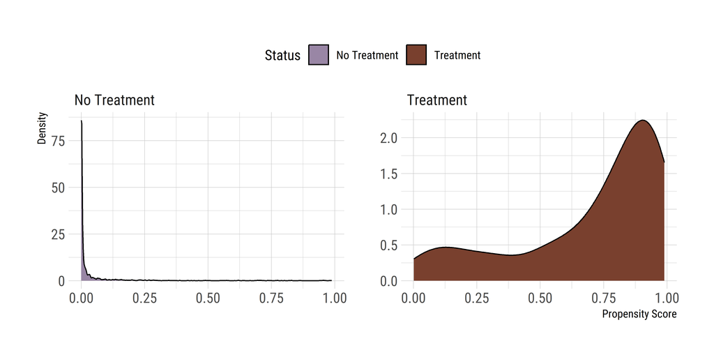

```r
# regression
lm.4 <- glm(
  as.formula(paste("treatment", "~", formula.hard, "+", "re74 + re75 + I(re74^2) + I(re75^2)")),
  data = d, family = binomial)

# propensity scores and visualization
d |>
  mutate(response = predict(lm.4, type = "response")) |>
  ggplot(aes(x = response, fill = treatment)) +
  geom_density() + facet_wrap(~ treatment, scale = "free") +
  scale_fill_manual(values = c("#9986A5", "#79402E")) +
  theme(legend.position = "top") +
  labs(x = "Propensity Score", y = "Density", fill = "Status")
```

Awesome! But what about those densities?

## Q5

The same formulation, this time with 1:1 nearest-neighbor matching:

```r
# matching
m.nn.nr <- matchit(
  as.formula(paste("treatment", "~", formula.hard, "+", "re74 + re75 + I(re74^2) + I(re75^2)")),
  data = d, method = "nearest", distance = "glm", replace = FALSE)

m.nn.yr <- matchit(
  as.formula(paste("treatment", "~", formula.hard, "+", "re74 + re75 + I(re74^2) + I(re75^2)")),
  data = d, method = "nearest", distance = "glm", replace = TRUE)

# bal plots

p1 <- bal.plot(m.nn.nr, var.name = "distance", which = "both",
               colors = c("#9986A5", "#79402E")) +
  theme(legend.position = "top") +
  labs(
    title = "Balance Without Replacement",
    x = "Propensity Score", y = "Density", fill = "Status")

p2 <- bal.plot(m.nn.yr, var.name = "distance", which = "both",
               colors = c("#9986A5", "#79402E")) +
  theme(legend.position = "top") +
  labs(
    title = "Balance With Replacement",
    x = "Propensity Score", y = "Density", fill = "Status")

p1 / p2
```

[figure not shown]

Balance with replacement is much better! This is probably because the common support is weak. Let’s look at it:

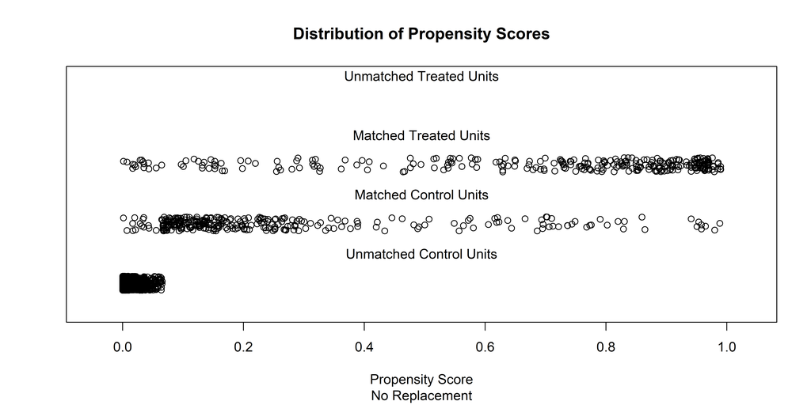

```r
plot(m.nn.nr, type = "jitter", interactive = FALSE, sub = "No Replacement")
```

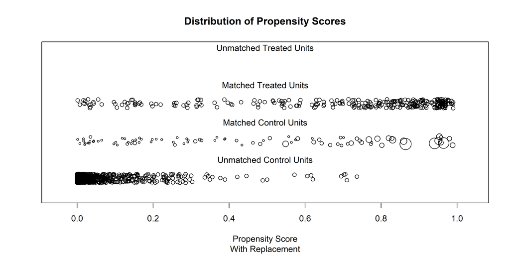

```r
plot(m.nn.yr, type = "jitter", interactive = FALSE, sub = "With Replacement")
```

Yes! As we can see, there are very few cases in the control group to correctly match with the treatment group. By using those observations more than once (with replacement), we give more flexibility to the algorithm.

Let’s estimate the treatment effects and compare:

```r
lm.5 <- lm(re78 ~ treatment, data = d, weights = m.nn.nr$weights)
lm.6 <- lm(re78 ~ treatment, data = d, weights = m.nn.yr$weights)

model_summary("No Replacement" = lm.5, "With Replacement" = lm.6)
```

|  | No Replacement | With Replacement |
| --- | --- | --- |
| (Intercept) | 9.81 | 5.97 |
|  | (0.51) | (0.72) |
| Treatment | −3.83 | 0.01 |
|  | (0.73) | (0.82) |
| R2 | 0.045 | 0.000 |

As we can see, there is a huge difference between the estimates, and the latter is closer to the experimental estimate.

## Q6

Yay, weighting time! Let me first build the weighting model:

```r
m.weight <- weightit(
    as.formula(paste("treatment", "~", formula.hard, "+", "re74 + re75 + I(re74^2) + I(re75^2)")),
    data = d, estimand = "ATT", method = "ps")
```

Alright. Let’s check the covariate balance:

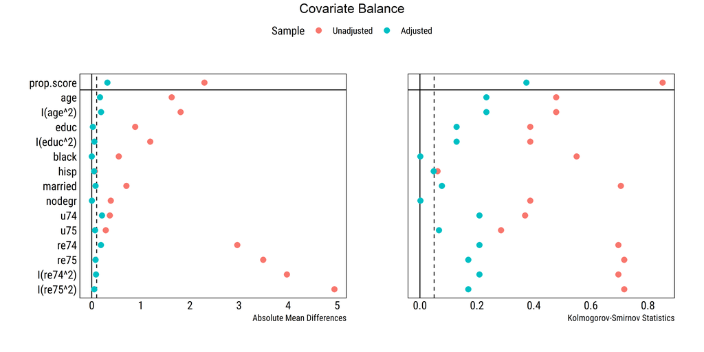

```r
love.plot(m.weight, abs = TRUE,
          stats = c("m", "ks"), thresholds = c(0.10, 0.05),
          position = "top")
```

This is not very good, and the KS Statistics are terrible. Let’s say it’s true, though. I am going to fit the model with these weights and present the treatment effect from that model:

```r
lm.7 <- lm(re78 ~ treatment, data = d, weights = m.weight$weights)
model_summary(lm.7)
```

|  | (1) |
| --- | --- |
| (Intercept) | 4.84 |
|  | (0.17) |
| Treatment | 1.14 |
|  | (0.27) |
| R2 | 0.007 |

This is also close to the experimental estimate.

## Q7

I am going to replicate the codes above, this time with covariate balancing propensity scores:

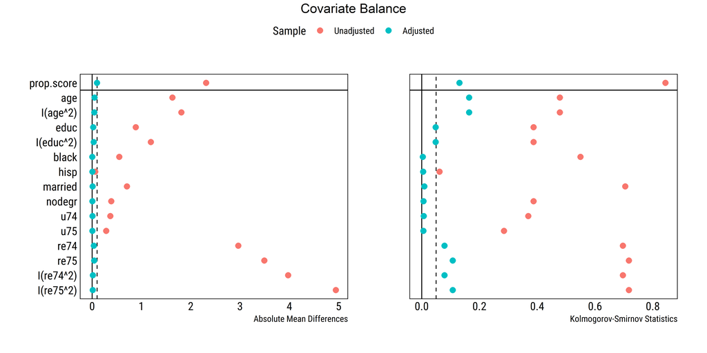

```r
# matching
m.weight.cb <- weightit(
    as.formula(paste("treatment", "~", formula.hard, "+", "re74 + re75 + I(re74^2) + I(re75^2)")),
    data = d, estimand = "ATT", method = "CBPS")

# love plot
love.plot(m.weight.cb, abs = TRUE,
          stats = c("m", "ks"), thresholds = c(0.10, 0.05),
          position = "top")
```

```r
# regression
lm.8 <- lm(re78 ~ treatment, data = d, weights = m.weight.cb$weights)
model_summary(lm.8)
```

|  | (1) |
| --- | --- |
| (Intercept) | 5.84 |
|  | (0.21) |
| Treatment | 0.13 |
|  | (0.29) |
| R2 | 0.000 |

## Q8

The same train continues! This time with Mahalanobis distance matching:

```r
# matching
m.mahala <- matchit(
    as.formula(paste("treatment", "~", formula.hard, "+", "re74 + re75 + I(re74^2) + I(re75^2)")),
    distance = "glm", caliper = 0.1,
    mahvars = c("age", "educ", "black", "hisp", "married", "nodegr", "re74", "re75", "u74", "u75"),
    data = d, estimand = "ATT", replace = TRUE)

summary(m.mahala)$nn |> round(0)
```

```
##               Control Treated
## All (ESS)        2213     297
## All              2213     297
## Matched (ESS)      28     278
## Matched            86     278
## Unmatched        2127      19
## Discarded           0       0
```

As we can see, 86 unique control cases are matched. It’s highly low!

## Q9

I am going to perform entropy balancing and look at the balance on means and variances:

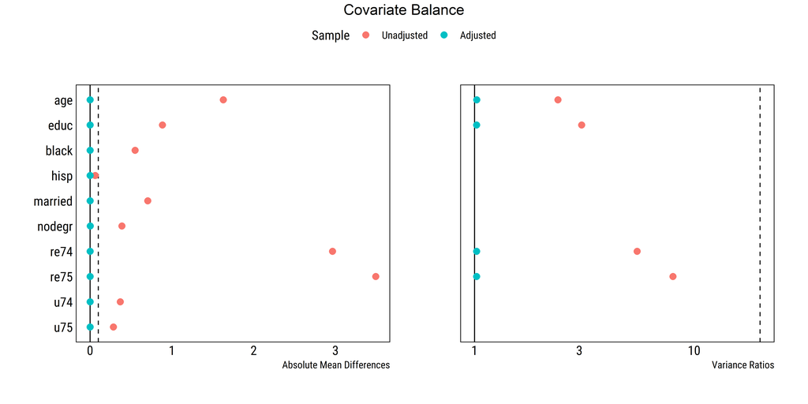

```r
# matching
m.weight.ent <- weightit(
    treatment ~ age + educ + black + hisp + married + nodegr + re74 + re75 + u74 + u75,
    data = d, method = "ebal", moments = 2, estimand = "ATT")

# love plot
love.plot(m.weight.ent, abs = TRUE,
          stats = c("m", "var"), thresholds = c(0.10, 0.05),
          position = "top")
```

Alright, as we can see there are strong balance on means. Since there is no variation for binary variables, the love plot above shows variance ratios for the continuous variables, which are also balanced.

## Q10

In what follows, I will estimate all the regressions that I presented above by using doubly robust estimations:

```r
# exact matching
lm.r.3 <- lm(
  as.formula(paste("re78", "~", "treatment", "+", formula.hard)),
  data = d, weights = m.exact$weights)

model_summary("Exact Matching" = lm.3, "Doubly-Robust Exact Matching" = lm.r.3)
```

|  | Exact Matching | Doubly-Robust Exact Matching |
| --- | --- | --- |
| (Intercept) | 8.24 | 3.44 |
|  | (0.23) | (2.77) |
| Treatment | −2.39 | −1.43 |
|  | (0.67) | (0.54) |
| R2 | 0.005 | 0.402 |

```r
# 1-to-1 matching with replacement
lm.r.6 <- lm(
  as.formula(paste("re78", "~", "treatment", "+", formula.hard)),
  data = d, weights = m.nn.yr$weights)

model_summary("1:1 with Replacement" = lm.6, "Doubly-Robust 1:1 with Replacement" = lm.r.6)
```

|  | 1:1 with Replacement | Doubly-Robust 1:1 with Replacement |
| --- | --- | --- |
| (Intercept) | 5.97 | 7.96 |
|  | (0.72) | (7.60) |
| Treatment | 0.01 | 0.01 |
|  | (0.82) | (0.81) |
| R2 | 0.000 | 0.071 |

```r
# weighted regression
lm.r.8 <- lm(
  as.formula(paste("re78", "~", "treatment", "+", formula.hard)),
  data = d, weights = m.weight$weights)

model_summary("PS Weighting" = lm.8, "Doubly-Robust PS Weighting" = lm.r.8)
```

[output not shown]

```r
# covariate balancing propensity score
lm.r.8 <- lm(
  as.formula(paste("re78", "~", "treatment", "+", formula.hard)),
  data = d, weights = m.weight.cb$weights)

model_summary("CBPS" = lm.8, "Doubly-Robust CBPS" = lm.r.8)
```

|  | CBPS | Doubly-Robust CBPS |
| --- | --- | --- |
| (Intercept) | 5.84 | 2.00 |
|  | (0.21) | (3.13) |
| Treatment | 0.13 | 0.24 |
|  | (0.29) | (0.28) |
| R2 | 0.000 | 0.116 |

```r
# mahalanobis distance matching
lm.9 <- lm(re78 ~ treatment, data = d, weights = m.mahala$weights)
lm.r.9 <- lm(
  as.formula(paste("re78", "~", "treatment", "+", formula.hard)),
  data = d, weights = m.mahala$weights)

model_summary("Mahalanobis" = lm.9, "Doubly-Robust Mahalanobis" = lm.r.9)
```

|  | Mahalanobis | Doubly-Robust Mahalanobis |
| --- | --- | --- |
| (Intercept) | 5.98 | 9.33 |
|  | (0.74) | (8.24) |
| Treatment | −0.08 | −0.47 |
|  | (0.85) | (0.84) |
| R2 | 0.000 | 0.088 |

## Q11

I really like bootstraps. Here is a function and implementation, following Noah Greifer’s excellent vignette. I will just use propensity score weighting, as it’s faster to implement.

```r
library(boot)

set.seed(11235)

# function
est.fun <- function(data, index) {
  w <-
    weightit(
      treat ~ age + I(age^2) + educ + I(educ^2) + black + hisp + married + nodegr + re74 + re75,
      data = data[index, ],
      estimand = "ATT", method = "ps")
  m <-
    glm(re78 ~ treat, data = data[index, ], weights = w$weights)
  return(coef(m)["treat"])
}

# bootstrap
boots <- boot(est.fun, data = d, R = 500)

# return the estimates
boots
```

```
##
## ORDINARY NONPARAMETRIC BOOTSTRAP
##
##
## Call:
## boot(data = d, statistic = est.fun, R = 500)
##
##
## Bootstrap Statistics :
##       original      bias    std. error
## t1* -0.3293975 -0.06694178   0.8573152
```

Yes! We see that the estimated standard error is $0.86$, which is pretty high!

Thank you!